# Generalized Additive Models

Teodoro MOUNIER TEBAS & Diane THIERRY

11/25/2020

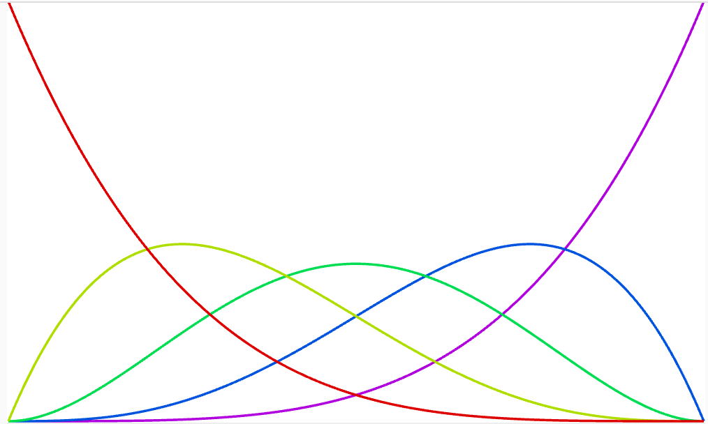

```r
knitr::include_graphics(here::here("./projet/images/bernsteinbasis.png"))
```

## Sommaire

- Introduction
- Manipulations et traitement des données
- Modélisations des temps des jobs
- Soumission des prévisions et conclusion

## Introduction

Le leader mondial ‘Talend’ de l’intégration et de l’intégrité des données dans le cloud, a annoncé le 30 juillet 2019 la disponibilité de **Stitch Data Loader** sur la marketplace d’Amazon Web Services (AWS). Déjà pertinente par sa portée et rendue d’autant plus accessible depuis cette annonce, la plateforme Stitch est devenue un incontournable dans la procuration de données ouvertes. Stitch Data Loader facilite en effet l’ingestion de données pour l’analyse et s’adapte automatiquement à l’augmentation du volume de données.

Cette plateforme est une composante de **Talend Data Fabric**, qui est une suite d’applications cloud conçues pour aider les clients à collecter, gérer, transformer et partager données et informations.

Pour ce projet, ont été récupérées différentes données issues de la plateforme *Stitch* concernant différentes requêtes effectuées, appelées « jobs » dont nous chercherons à prédire la durée en secondes.

- Nous disposons pour cela de 2 bases :
  - une base d’entraînement (« train ») composée de 9.100 observations et 5 variables
  - une base de test (« test ») composée de 1.700 observations et 5 variables

Le but de ce projet est de créer des modèles additifs généralisés qui prédisent au mieux le temps de durée de chaque *job* sur la plateforme Stitch. Nous construirons pour cela différents GAM sur la base d’entraînement, modèles que nous chercherons à optimiser pour les rendre les plus performants possible, puis nous les appliquerons sur la base ‘test’ où nous espérons les erreurs les plus faibles.

Dans un premier temps nous appelons les **librairies** qu’il nous faut pour réaliser le projet :

```r
library(tidyverse)
library(readr)
library(gganimate)
library(viridis)
library(gridExtra)
library(summarytools)
library(kableExtra)
library(knitr)
library(flextable)
library(tsoutliers)
library(EnvStats)
library(stringr)
library(seastests)
#install.packages("rAmCharts")
library(rAmCharts)
library(mgcv)
library(car)
library(tinytex)
library(xtable)
library(r2d3)
```

## 1-Manipulations et traitement des données

### 1.1 Téléchargement des données

Nous avons téléchargé les données depuis la plateforme Kaggle :

```r
train <- read_csv('./Données/data_train.csv')
test <- read_csv('./Données/data_test.csv')
```

Comme évoqué précédemment, les données brutes contiennent 5 variables et 9100 observations.

Nous disposons initialement de 6 variables :

- **JOB_DURATION** : durée de la requête Stitch, en secondes - notre variable à expliquer ($Y_i$) qui n’est disponible qu’en base ‘train’ puisque nous chercherons à la prédire avec la base test
- **TAP_EXIT_STATUS** : variable binaire qui indique si le job s’est exécuté, 0 si oui et 1 sinon
- **START_TIME** : l’heure de début de la requête
- **CONNECTION_ID** : variable composée de 3 modalités indiquant l’identifiant de la chronique (1, 2 ou 3)
- **TAP_VERSION** : version du *Terminal Access Point* utilisée qui est plus ou moins récente, le TAP est un dispositif permettant de surveiller un réseau informatique sans le perturber.
- **ID** : disponible uniquement dans la base ‘test’, permet d’identifier l’utilisateur

### 1.2 Premières informations sur les variables

Nous regardons les 5 premières lignes de notre jeu de données pour nous rendre compte des informations qu’il contient. Nous pouvons aussi regarder le format des variables grâce à la commande **str()**. Puis, le *summary* de la base nous donnera un aperçu des distributions des variables avec les valeurs minimales et maximales de chacune d’elle ainsi que la moyenne, les quartiles etc. Le but de cette analyse exploratoire étant de cerner au mieux les données pour éventuellement créer de nouvelles variables ou transformer les existantes.

```r
s <- head(train,10)
kbl(s, align = "c") %>%  kable_minimal() %>% kable_styling(font_size = 11)
```

| CONNECTION_ID | START_TIME | TAP_VERSION | TAP_EXIT_STATUS | JOB_DURATION |
| --- | --- | --- | --- | --- |
| 1 | 2019-10-11 13:41:00 | 1.15.1 | 0 | 9 |
| 1 | 2019-10-11 14:41:00 | 1.15.1 | 0 | 9 |
| 1 | 2019-10-11 15:41:00 | 1.15.1 | 0 | 12 |
| 1 | 2019-10-11 16:41:00 | 1.15.1 | 0 | 10 |
| 1 | 2019-10-11 17:41:00 | 1.15.1 | 0 | 11 |
| 1 | 2019-10-11 18:41:00 | 1.15.1 | 0 | 10 |
| 1 | 2019-10-11 19:41:00 | 1.15.1 | 0 | 10 |
| 1 | 2019-10-11 20:41:00 | 1.15.1 | 0 | 11 |
| 1 | 2019-10-11 21:41:00 | 1.15.1 | 0 | 10 |
| 1 | 2019-10-11 22:41:00 | 1.15.1 | 0 | 11 |

On constate d’emblée que notre variable à expliquer “JOB_DURATION” correspond à la cinquième colonne, et que la variable “START_TIME” regroupe à la fois les dates et les heures du début des jobs. À partir des 10 premières observations, on voit que les variables “CONNECTION_ID”, “TAP_VERSION” et “TAP_EXIT_STATUS” restent inchangées, ce qui n’est pas le cas de “JOB_DURATION” qui évolue en fonction du temps récupéré par la variable “START_TIME”. De plus, les durées des 10 premiers *jobs* sont très courtes, allant de 9 à 12 secondes.

```r
str(train)
## tibble [9,100 x 5] (S3: spec_tbl_df/tbl_df/tbl/data.frame)
##  $ CONNECTION_ID  : num [1:9100] 1 1 1 1 1 1 1 1 1 1 ...
##  $ START_TIME     : POSIXct[1:9100], format: "2019-10-11 13:41:00" "2019-10-11 14:41:00" ...
##  $ TAP_VERSION    : chr [1:9100] "1.15.1" "1.15.1" "1.15.1" "1.15.1" ...
##  $ TAP_EXIT_STATUS: num [1:9100] 0 0 0 0 0 0 0 0 0 0 ...
##  $ JOB_DURATION   : num [1:9100] 9 9 12 10 11 10 10 11 10 11 ...
##  - attr(*, "spec")=
##   .. cols(
##   ..   CONNECTION_ID = col_double(),
##   ..   START_TIME = col_datetime(format = ""),
##   ..   TAP_VERSION = col_character(),
##   ..   TAP_EXIT_STATUS = col_double(),
##   ..   JOB_DURATION = col_double()
##   .. )
```

Sur nos 5 variables seules 3 sont numériques ; “TAP_VERSION” est en format ‘character’ et “START_TIME” au format ‘POSIXct’ ce que nous devrons donc changer pour un meilleur traitement des données.

```r
summary(train)
##  CONNECTION_ID     START_TIME                  TAP_VERSION
##  Min.   :1.000   Min.   :2019-10-11 13:41:00   Length:9100
##  1st Qu.:1.000   1st Qu.:2020-01-11 05:31:00   Class :character
##  Median :1.000   Median :2020-02-27 21:50:30   Mode  :character
##  Mean   :1.626   Mean   :2020-03-19 21:41:01
##  3rd Qu.:2.000   3rd Qu.:2020-07-13 01:46:30
##  Max.   :3.000   Max.   :2020-08-29 11:09:00
##
##  TAP_EXIT_STATUS    JOB_DURATION
##  Min.   :0.00000   Min.   :   2.0
##  1st Qu.:0.00000   1st Qu.:  10.0
##  Median :0.00000   Median :  14.0
##  Mean   :0.00099   Mean   : 400.5
##  3rd Qu.:0.00000   3rd Qu.: 181.0
##  Max.   :1.00000   Max.   :4349.0
##  NA's   :11
```

On voit que sur les 3 modalités de connexion, la 1 regroupe au moins la moitié des observations puisque la médiane est de 1. On constate aussi que les requêtes de la base train s’étendent du 11 octobre 2019 au 29 août 2020. Concernant la variable “TAP_EXIT_STATUS” c’est la seule qui contient des valeurs manquantes, il faudra donc retirer ces 11 observations pour les modélisations. Enfin, on voit que les durées des requêtes vont de 2 secondes à 4349 soit 1 heure 12 minutes et 29 secondes, ce qui est considérable. On peut donc supposer que le job n’a pas abouti (TAP_EXIT_STATUS=1) ou bien qu’il existe une grande disparité des temps au sein des périodes. On voit ainsi que la moyenne est de 400 secondes tandis que la médiane est de seulement 14.

### 1.3 Visulation des données

Avant toute transformation des variables nous allons visualiser la variable à expliquer en fonction du temps.

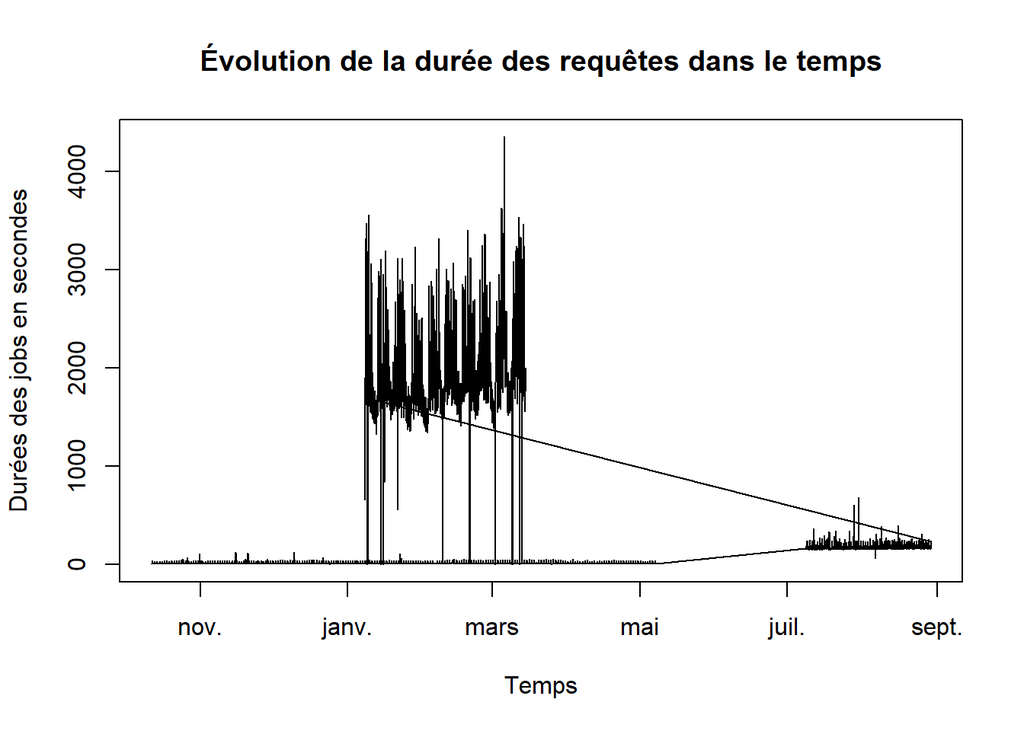

```r
# On plot la variable à expliquer fonction du temps
plot(train$JOB_DURATION ~ train$START_TIME, type='l', xlab="Temps", ylab="Durées des jobs en secondes", main="Évolution de la durée des requêtes dans le temps")
```

Au vu du graphique ci-dessus on peut constater qu’il y a 3 périodes correspondant aux 3 chroniques :

- la première s’étend d’octobre à mai 2020 avec une volatilité très faible donc un temps des jobs très court
- la seconde de juillet à septembre comprenant donc l’été, avec des temps légèrement plus longs que ceux de la première période liés probablement aux vacances scolaires d’été
- la dernière s’étend de janvier à fin mars avec cette fois des temps beaucoup plus importants qui semblent varier autour de 2000 secondes soit 33 minutes

La connexion ID n°3 se distingue donc largement des chroniques 1 et 2 par sa grande volatilité de temps des jobs, malgré le fait qu’elle ait été capturée sur une sous-période de la chronique 1. Compte tenu du fait que les valeurs des jobs diffèrent beaucoup d’une chronique à l’autre, nous allons procéder à la division de notre base en 3 sous bases pour chaque chronique, dans le but d’observer plus précisément les variations des temps des jobs.

#### ID 1

```r
# On créé une sous-base pour la chronique n°1
df_ID1 <- train %>% filter(CONNECTION_ID==1)
summary(df_ID1)
##  CONNECTION_ID   START_TIME                  TAP_VERSION        TAP_EXIT_STATUS
##  Min.   :1     Min.   :2019-10-11 13:41:00   Length:5000        Min.   :0
##  1st Qu.:1     1st Qu.:2019-12-02 14:26:00   Class :character   1st Qu.:0
##  Median :1     Median :2020-01-23 16:11:00   Mode  :character   Median :0
##  Mean   :1     Mean   :2020-01-23 22:53:32                      Mean   :0
##  3rd Qu.:1     3rd Qu.:2020-03-16 09:56:00                      3rd Qu.:0
##  Max.   :1     Max.   :2020-05-07 12:41:00                      Max.   :0
##   JOB_DURATION
##  Min.   :  7.00
##  1st Qu.: 10.00
##  Median : 10.00
##  Mean   : 12.25
##  3rd Qu.: 12.00
##  Max.   :128.00
```

La sous base de la chronique 1 ainsi créée contient 55% de la base train pour un total de 5000 observations. Nous constatons que pour la variable “TAP_EXIT_STATUS” il n’y a plus de valeur manquante, celles-ci devaient donc concerner les chroniques 2 ou 3 (nous verrons cela juste après). En revanche si l’on regarde la durée des jobs, on voit que le temps maximal est de 128 secondes, il s’agit sûrement d’une valeur atypique qui peut gêner nos modélisations et que nous allons donc traiter dès maintenant.

```r
amBoxplot(df_ID1$JOB_DURATION, xlab="CONNECTION ID n°1", ylab="Durée des jobs", main="Boxplot 'JOB_DURATION' pour la chronique n°1")
```

[interactive chart not shown]

À partir du graphique ci-dessus, nous observons d’emblée que de nombreuses observations sont supérieures au troisième quantile et peuvent donc être considérées comme atypiques. Cependant, étant donné le nombre important de points concernés il peut s’agir d’un comportement explicable et qui peut apporter une information importante pour les futures modélisations. Nous considérons donc comme atypiques les valeurs qui dépassent 1 minute car il n’y en a que 8 qui sont assez espacées, et procédons au test de Rosner pour confirmer leur atypicité.

```r
rosnerTest(df_ID1$JOB_DURATION, k = 8, alpha = 0.05) # 8 outliers : 128,126,121,114,108,76,75,65
```

```r
# On regarde à quelles dates les points correspondent pour voir si pattern
a <- df_ID1 %>% slice(1423,846,967,2479,487,1711,366,2489)
kbl(a, align = "c") %>% kable_classic(full_width = F, html_font = "Cambria")
```

| CONNECTION_ID | START_TIME | TAP_VERSION | TAP_EXIT_STATUS | JOB_DURATION |
| --- | --- | --- | --- | --- |
| 1 | 2019-12-09 18:41:00 | 1.15.1 | 0 | 128 |
| 1 | 2019-11-15 17:41:00 | 1.15.1 | 0 | 126 |
| 1 | 2019-11-20 18:41:00 | 1.15.1 | 0 | 121 |
| 1 | 2020-01-22 18:41:00 | 1.15.1 | 0 | 114 |
| 1 | 2019-10-31 18:41:00 | 1.15.1 | 0 | 108 |
| 1 | 2019-12-21 18:41:00 | 1.15.1 | 0 | 76 |
| 1 | 2019-10-26 18:41:00 | 1.15.1 | 0 | 75 |
| 1 | 2020-01-23 04:41:00 | 1.15.1 | 0 | 65 |

D’après le test de Rosner on voit que les 8 observations étaient effectivement atypiques, nous trouvions intéressant de regarder de quelles observations il s’agissait pour noter d’éventuels comportements communs par exemple par heure ou par jour de la semaine. Nous observons alors d’après la table que la plupart des observations atypiques se situent en fin d’après-midi à 18h41 (c’est le cas de 6 observations sur 8). On ne note cependant pas de régularité dans les jours de la semaine puisque l’on retrouve 2 fois mercredi, jeudi et samedi, et 1 fois lundi et vendredi.

```r
  # on crée une nouvelle base sans ces points
df_ID1=df_ID1[-c(1423,846,967,2479,487,1711,366,2489),]
dim(df_ID1)
## [1] 4992    5
amBoxplot(df_ID1$JOB_DURATION, xlab="CONNECTION ID n°1", ylab="Durée des jobs", main="Boxplot 'JOB_DURATION' débarrassé des points atypiques")
```

[interactive chart not shown]

On retire donc les 8 observations de la base **df_ID1**, et en effectuant à nouveau un diagramme à moustaches on observe que les observations sont assez rapprochées les unes des autres et peuvent ainsi nous apporter de l’information (en cliquant dessus on voit que les valeurs les plus élevées hors de la boîte sont à 58 secondes). Nous allons à présent regarder les temps de durée des requêtes Stitch pour la chronique 1 en visualisant pour toute la base, par journée, par semaine et par mois; l’objectif étant de noter une possible saisonnalité pour la variable à expliquer “JOB_DURATION”.

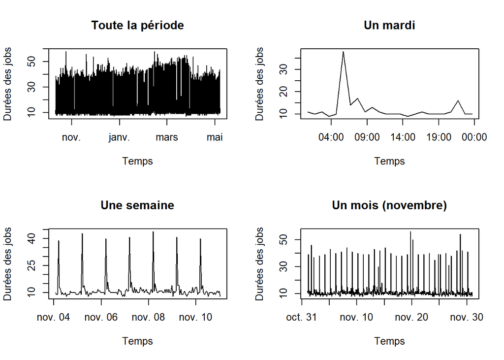

```r
  # Graphiques CONNECTION_ID 1
par(mfrow=c(2,2))
plot(JOB_DURATION ~ START_TIME, type='l', data=df_ID1, main="Toute la période", xlab="Temps", ylab="Durées des jobs") # le tout
plot(JOB_DURATION ~ START_TIME, type='l', data=df_ID1[84:107,], main="Un mardi", xlab="Temps", ylab="Durées des jobs")  # mardi
plot(JOB_DURATION ~ START_TIME, type='l', data=df_ID1[564:731,], main="Une semaine", xlab="Temps", ylab="Durées des jobs")  # une semaine
plot(JOB_DURATION ~ START_TIME, type='l', data=df_ID1[491:1208,], main="Un mois (novembre)", xlab="Temps", ylab="Durées des jobs")  # un mois
```

On peut constater à partir des 4 graphiques des tendances :

- chaque journée commence avec un pic significatif autour de 6 heures du matin, puis un autre plus faible en fin de journée
- ces pics où les temps des jobs sont élevés, sont visibles pour chaque jour de la semaine peu importe qu’il s’agisse d’un week end ou d’un début de semaine
- pour le mois de novembre on retrouve ces pics avec quelques valeurs plus grandes mais non régulières

##### Évolution de Y sur plusieurs semaines

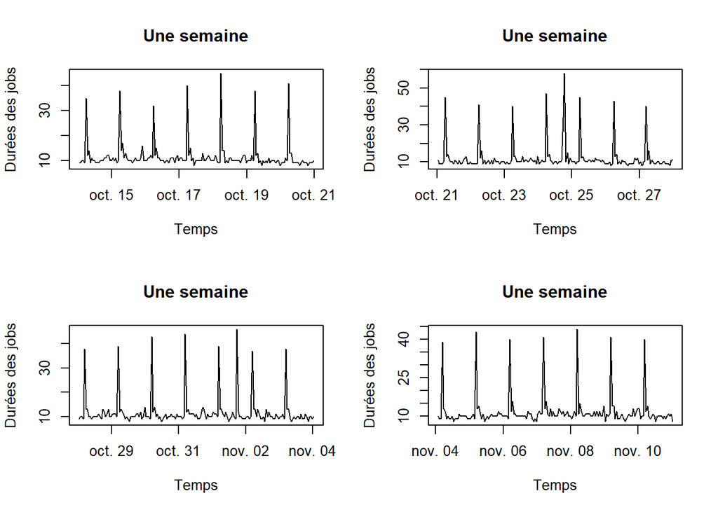

```r
par(mfrow=c(2,2))
plot(JOB_DURATION ~ START_TIME, type='l', data=df_ID1[60:227,], main="Une semaine", xlab="Temps", ylab="Durées des jobs")
plot(JOB_DURATION ~ START_TIME, type='l', data=df_ID1[228:395,], main="Une semaine", xlab="Temps", ylab="Durées des jobs")
plot(JOB_DURATION ~ START_TIME, type='l', data=df_ID1[396:563,], main="Une semaine", xlab="Temps", ylab="Durées des jobs")
plot(JOB_DURATION ~ START_TIME, type='l', data=df_ID1[564:731,], main="Une semaine", xlab="Temps", ylab="Durées des jobs")
```

##### Évolution de Y sur plusieurs mois

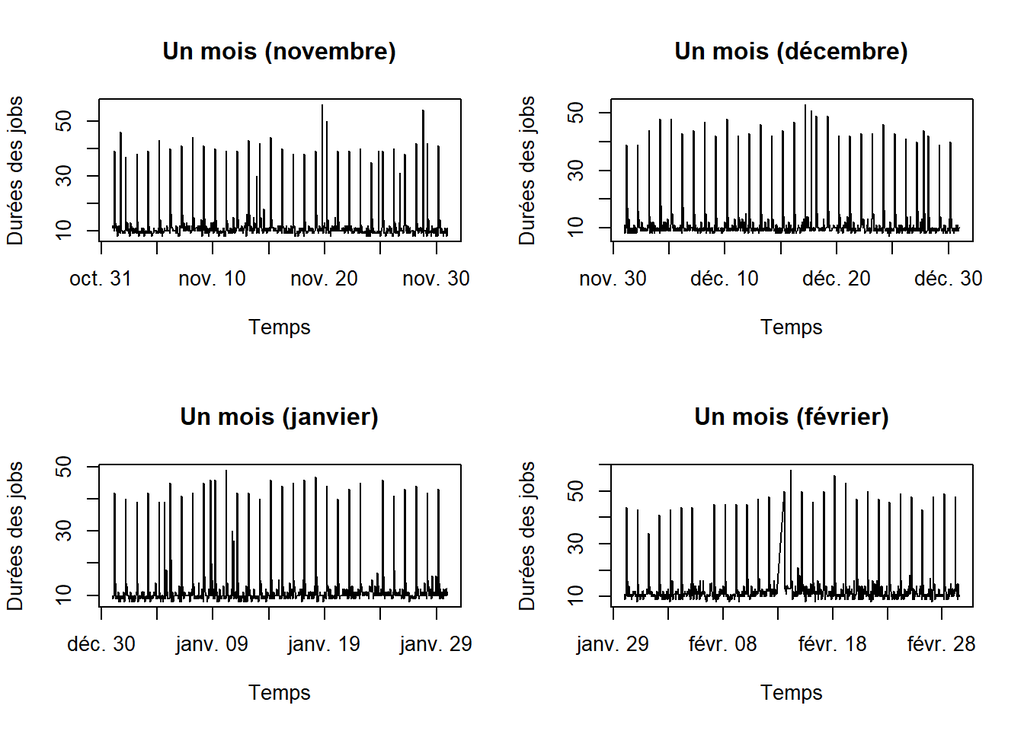

```r
par(mfrow=c(2,2))
plot(JOB_DURATION ~ START_TIME, type='l', data=df_ID1[491:1208,], main="Un mois (novembre)", xlab="Temps", ylab="Durées des jobs")
plot(JOB_DURATION ~ START_TIME, type='l', data=df_ID1[1209:1926,], main="Un mois (décembre)", xlab="Temps", ylab="Durées des jobs")
plot(JOB_DURATION ~ START_TIME, type='l', data=df_ID1[1927:2644,], main="Un mois (janvier)", xlab="Temps", ylab="Durées des jobs")
plot(JOB_DURATION ~ START_TIME, type='l', data=df_ID1[2645:3362,], main="Un mois (février)", xlab="Temps", ylab="Durées des jobs")
```

#### ID 2

```r
# On créé une sous-base pour la chronique n°2
df_ID2 <- train %>% filter(CONNECTION_ID==2)
summary(df_ID2)
##  CONNECTION_ID   START_TIME                  TAP_VERSION
##  Min.   :2     Min.   :2020-07-08 09:39:00   Length:2500
##  1st Qu.:2     1st Qu.:2020-07-21 10:01:30   Class :character
##  Median :2     Median :2020-08-03 10:24:00   Mode  :character
##  Mean   :2     Mean   :2020-08-03 10:24:00
##  3rd Qu.:2     3rd Qu.:2020-08-16 10:46:30
##  Max.   :2     Max.   :2020-08-29 11:09:00
##
##  TAP_EXIT_STATUS     JOB_DURATION
##  Min.   :0.000000   Min.   : 67.0
##  1st Qu.:0.000000   1st Qu.:165.8
##  Median :0.000000   Median :172.0
##  Mean   :0.001601   Mean   :178.4
##  3rd Qu.:0.000000   3rd Qu.:182.0
##  Max.   :1.000000   Max.   :688.0
##  NA's   :1
```

Nous réitérons l’analyse pour la chronique 2 en créant une autre sous base pour cet ID qui contient cette fois 2500 observations. On voit cette fois que la durée moyenne des jobs est beaucoup plus importante que pour la chronique 1 variant autour de 178 secondes. De plus nous observons qu’il y a une valeur manquante pour la variable “TAP_EXIT_STATUS” que nous retirons avant la détection des outliers.

```r
#on supprime la valeur manquante pour "TAP_EXIT_STATUS" (6 aout 2020)
df_ID2 <- na.omit(df_ID2)
#on regarde le boxplot
amBoxplot(df_ID2$JOB_DURATION, xlab="CONNECTION ID n°2", ylab="Durée des jobs", main="Boxplot 'JOB_DURATION' pour la chronique n°2")
```

[interactive chart not shown]

```r
b <- df_ID2 %>% slice(1062,977)
kbl(b, align = "c") %>% kable_classic(full_width = F, html_font = "Cambria")
```

| CONNECTION_ID | START_TIME | TAP_VERSION | TAP_EXIT_STATUS | JOB_DURATION |
| --- | --- | --- | --- | --- |
| 2 | 2020-07-30 12:09:00 | 1.4.33 | 0 | 688 |
| 2 | 2020-07-28 17:39:00 | 1.4.33 | 0 | 604 |

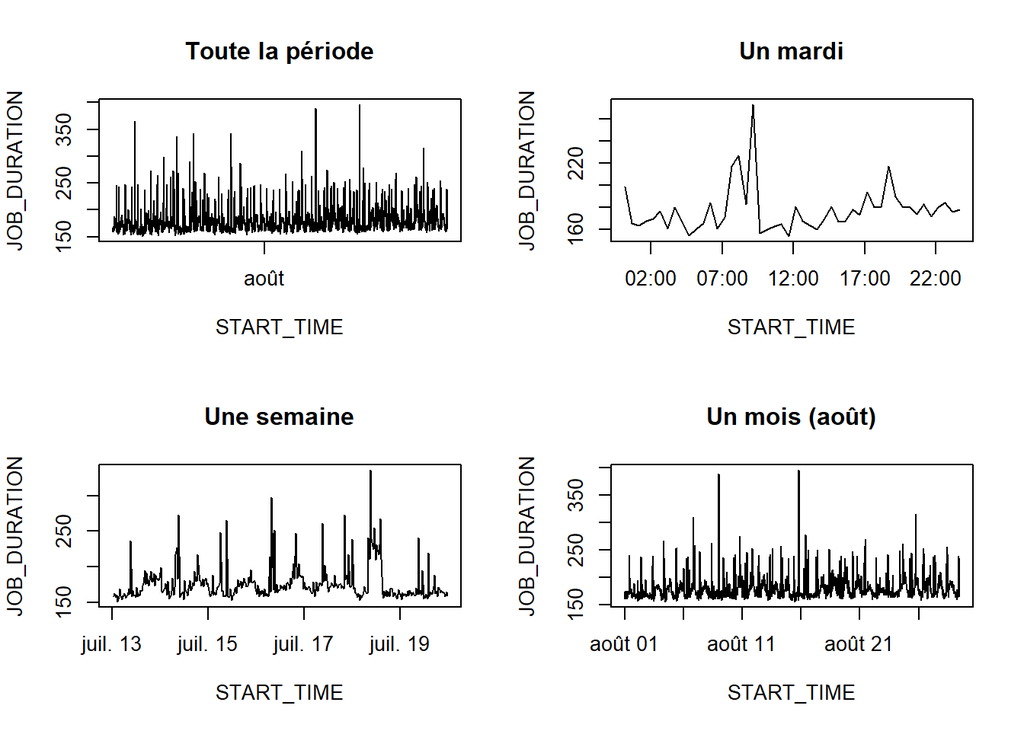

```r
  # Graphiques CONNECTION_ID 2
par(mfrow=c(2,2))
plot(JOB_DURATION ~ START_TIME, type='l', data=df_ID2, main="Toute la période") # le tout
plot(JOB_DURATION ~ START_TIME, type='l', data=df_ID2[270:317,], main="Un mardi")  # mardi
plot(JOB_DURATION ~ START_TIME, type='l', data=df_ID2[222:557,], main="Une semaine")  # une semaine
plot(JOB_DURATION ~ START_TIME, type='l', data=df_ID2[1132:2497,], main="Un mois (août)")  # un mois
```

Par rapport aux graphiques de la chronique une, on retrouve le pic du temps des jobs de début de journée assez grand et un pic plus faible en fin d’après-midi. En revanche on constate que le pic de début de journée est légèrement plus tard qu’en période “scolaire” puisque nous le rappelons la chronique 2 concerne les mois de juillet et août 2020.

##### Évolution de Y sur plusieurs semaines

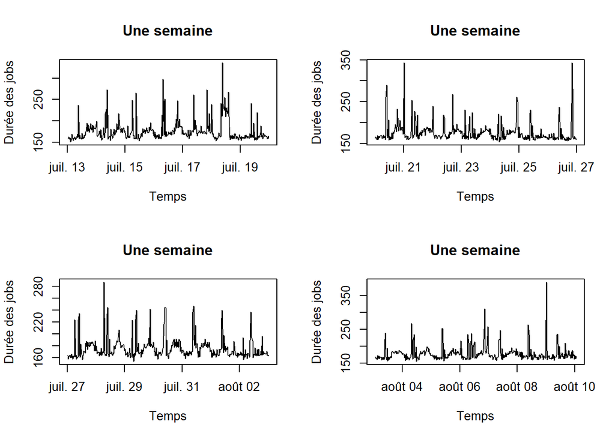

```r
par(mfrow=c(2,2))
plot(JOB_DURATION ~ START_TIME, type='l', data=df_ID2[222:557,], main="Une semaine", ylab="Durée des jobs", xlab="Temps")
plot(JOB_DURATION ~ START_TIME, type='l', data=df_ID2[558:893,], main="Une semaine", ylab="Durée des jobs", xlab="Temps")
plot(JOB_DURATION ~ START_TIME, type='l', data=df_ID2[894:1229,], main="Une semaine", ylab="Durée des jobs", xlab="Temps")
plot(JOB_DURATION ~ START_TIME, type='l', data=df_ID2[1230:1565,], main="Une semaine", ylab="Durée des jobs", xlab="Temps")
```

#### ID 3

```r
# On créé une sous-base pour la chronique n°3
df_ID3 <- train %>% filter(CONNECTION_ID==3)
summary(df_ID3)
##  CONNECTION_ID   START_TIME                  TAP_VERSION
##  Min.   :3     Min.   :2020-01-08 03:02:00   Length:1600
##  1st Qu.:3     1st Qu.:2020-01-24 17:45:00   Class :character
##  Median :3     Median :2020-02-10 09:30:00   Mode  :character
##  Mean   :3     Mean   :2020-02-10 10:02:12
##  3rd Qu.:3     3rd Qu.:2020-02-27 01:15:00
##  Max.   :3     Max.   :2020-03-14 19:00:00
##
##  TAP_EXIT_STATUS     JOB_DURATION
##  Min.   :0.000000   Min.   :   2
##  1st Qu.:0.000000   1st Qu.:1664
##  Median :0.000000   Median :1824
##  Mean   :0.003145   Mean   :1961
##  3rd Qu.:0.000000   3rd Qu.:2165
##  Max.   :1.000000   Max.   :4349
##  NA's   :10
```

Finalement, nous réalisons une troisième fois l’analyse pour la dernière connexion : la base contient alors 1600 observations et 10 valeurs manquantes que nous enlevons de la base. Pour cette période de janvier à mars 2020 on voit que les durées des requêtes sont encore plus élevées que la chronique 2.

```r
#on supprime les 10 valeurs manquantes pour "TAP_EXIT_STATUS"
df_ID3 <- na.omit(df_ID3)
#on regarde le boxplot
amBoxplot(df_ID3$JOB_DURATION, xlab="CONNECTION ID n°3", ylab="Durée des jobs", main="Boxplot 'JOB_DURATION' pour la chronique n°3")
```

[interactive chart not shown]

```r
# Find valeurs atypiques
aa <- df_ID3 %>% filter(JOB_DURATION < 1000)
bb <- df_ID3 %>% filter(JOB_DURATION > 4000)
cc <- rbind(bb,aa)
kbl(cc, align = "c") %>% kable_classic(full_width = F)
```

| CONNECTION_ID | START_TIME | TAP_VERSION | TAP_EXIT_STATUS | JOB_DURATION |
| --- | --- | --- | --- | --- |
| 3 | 2020-03-05 21:00:00 | 2.6.5 | 0 | 4349 |
| 3 | 2020-01-08 06:01:00 | 2.6.4 | 0 | 660 |
| 3 | 2020-01-16 05:01:00 | 2.6.4 | 1 | 841 |
| 3 | 2020-01-21 20:00:00 | 2.6.4 | 0 | 562 |
| 3 | 2020-02-09 07:01:00 | 2.6.4 | 1 | 16 |
| 3 | 2020-03-02 01:01:00 | 2.6.5 | 1 | 7 |
| 3 | 2020-03-13 01:01:00 | 2.6.5 | 1 | 8 |

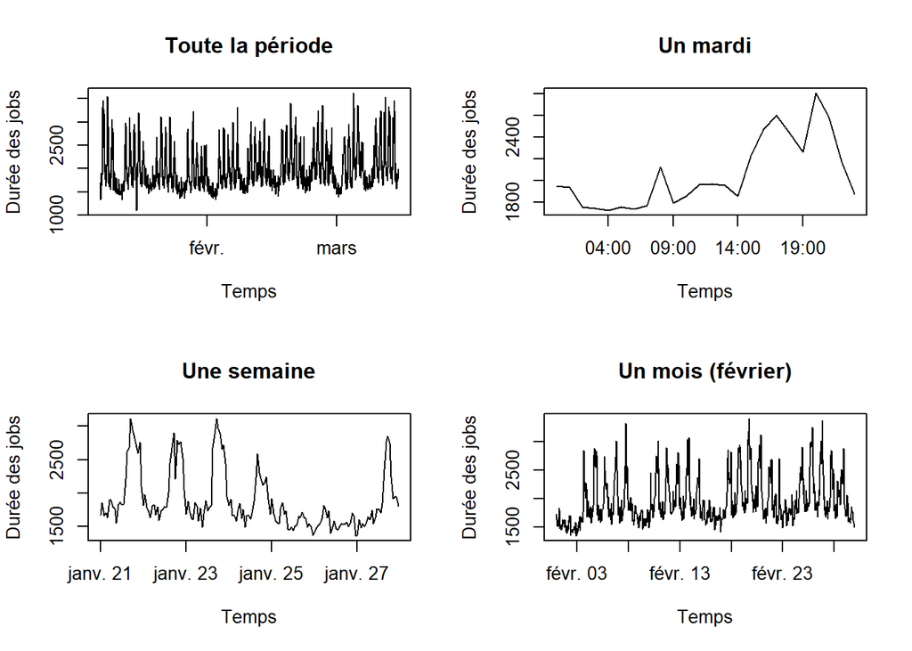

```r
  # Graphiques CONNECTION_ID 3
par(mfrow=c(2,2))
plot(JOB_DURATION ~ START_TIME, type='l', data=df_ID3, main="Toute la période", ylab="Durée des jobs", xlab="Temps") # le tout
plot(JOB_DURATION ~ START_TIME, type='l', data=df_ID3[829:852,], main="Un mardi", ylab="Durée des jobs", xlab="Temps")  # mardi
plot(JOB_DURATION ~ START_TIME, type='l', data=df_ID3[304:469,], main="Une semaine", ylab="Durée des jobs", xlab="Temps")  # une semaine
plot(JOB_DURATION ~ START_TIME, type='l', data=df_ID3[566:1259,], main="Un mois (février)", ylab="Durée des jobs", xlab="Temps")  # un mois
```

On peut constater plusieurs choses cette fois-ci :

- dans la journée le pic où le temps de job est le plus élevé est en fin d’après midi et non le matin
- dans une semaine on voit la plus grande rapidité des requêtes le week-end hormis le dimanche soir
- les graphiques du mois et de toute la période confirment cet “effet week-end”

##### Évolution de Y sur plusieurs semaines

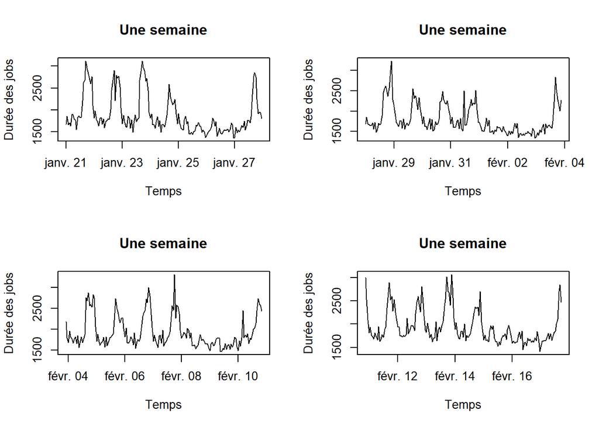

```r
par(mfrow=c(2,2))
plot(JOB_DURATION ~ START_TIME, type='l', data=df_ID3[304:469,], main="Une semaine", ylab="Durée des jobs", xlab="Temps")
plot(JOB_DURATION ~ START_TIME, type='l', data=df_ID3[470:635,], main="Une semaine", ylab="Durée des jobs", xlab="Temps")
plot(JOB_DURATION ~ START_TIME, type='l', data=df_ID3[636:801,], main="Une semaine", ylab="Durée des jobs", xlab="Temps")
plot(JOB_DURATION ~ START_TIME, type='l', data=df_ID3[802:966,], main="Une semaine", ylab="Durée des jobs", xlab="Temps")
```

Cette partie nous a permis de constater la proximité des temps de jobs pour les chroniques 1 et 2 quoiqu’un peu plus longues pour la chronique 2 du fait peut être de l’été. En revanche les temps d’attente des jobs de la chronique 3 sont eux beaucoup plus importants avec des pics à des horaires différents des autres CONNECTION_ID.

### 1.4 Transformation des variables

Nous allons procéder à la transformation des variables qui nous ont semblées pertinentes dans l’explication du temps des jobs. Ayant découpé l’échantillon ‘train’ en 3 sous-bases selon la chronique, la seule variable qui reste pertinente pour l’explication des jobs est la variable “START_TIME”. A partir de cette dernière nous allons pouvoir extraire plusieurs informations pour expliquer le temps des jobs. En découpant “START_TIME” en nombre d’heures par jour, des “paterns” ont été mis en évidence quelles que soit la chronique. Lorsque nous avons découpé cette variable par semaine pour voir si le jour de la semaine pouvait influencer le temps des jobs, nous nous sommes rendu compte que seule la chronique 3 semblait être affectée par le samedi et dimanche que nous avons appelé précédemment “effet week-end”. Enfin, lorsque l’on a observé Y sur plusieurs mois nous n’avons pas noté de ressemblances ou de tendances d’un mois à l’autre. Dans tous les cas nous faisons le choix d’extraire de la variable “START_TIME” l’heure de la journée qui nous semble être la variable la plus importante, le jour de la semaine et la semaine de l’année, tels que :

- **Week** : le numéro de la semaine dans l’année, les valeurs iront donc de 1 à 52
- **Day** : le jour dans la semaine avec ainsi des valeurs allant de 1 à 7
- **Hour** : l’heure de la journée

```r
# On crée toutes ces variables en séparant chaque info de 'Start_time'

    # Semaine de l'année
df_ID1$Week <- format(df_ID1$START_TIME, format = "%U")
df_ID2$Week <- format(df_ID2$START_TIME, format = "%U")
df_ID3$Week <- format(df_ID3$START_TIME, format = "%U")

    # Jours de la semaine
        #on récupère le nom de la semaine
df_ID1$Day <- format(df_ID1$START_TIME, format = "%A")
df_ID2$Day <- format(df_ID2$START_TIME, format = "%A")
df_ID3$Day <- format(df_ID3$START_TIME, format = "%A")
        #on convertit le nom en chiffre
df_ID1$Day <- str_replace_all(df_ID1$Day, c("lundi"="1", "mardi"="2", "mercredi"="3", "jeudi"="4", "vendredi"="5", "samedi"="6", "dimanche"="7"))
df_ID2$Day <- str_replace_all(df_ID2$Day, c("lundi"="1", "mardi"="2", "mercredi"="3", "jeudi"="4", "vendredi"="5", "samedi"="6", "dimanche"="7"))
df_ID3$Day <- str_replace_all(df_ID3$Day, c("lundi"="1", "mardi"="2", "mercredi"="3", "jeudi"="4", "vendredi"="5", "samedi"="6", "dimanche"="7"))

    # Heures
df_ID1$Hour <- format(df_ID1$START_TIME, format = "%H")
df_ID2$Hour <- format(df_ID2$START_TIME, format = "%H.%M") #on ajoute les minutes puisqu'il y a 2 obs par heure pour l'ID2
df_ID3$Hour <- format(df_ID3$START_TIME, format = "%H")

# On garde dans une variable juste la date sans l'heure
df_ID1$Date <- as.Date(df_ID1$START_TIME, format = "%m-%d-%Y")
df_ID2$Date <- as.Date(df_ID2$START_TIME, format = "%m-%d-%Y")
df_ID3$Date <- as.Date(df_ID3$START_TIME, format = "%m-%d-%Y")
```

Les commandes ci-dessus permettent donc de créer les différentes variables. Ce processus d’extraction transforme les variables créées en ‘caractère’, or les modèles GAM ne supportent pas ce format pour les modélisations donc nous les convertissons au format numérique par la fonction *as.numeric()* seulement pour la variable ‘Hour’ qui prend les heures et les minutes pour l’ID2, sinon nous appliquons la fonction *as.integer()* pour les autres variables puisque les valeurs sont discrètes.

Nous voilà désormais avec 9 variables par sous-base de chronique. L’intérêt de séparer quelques informations contenues dans la variable ‘START_TIME’ se trouve dans les modélisations GAM : le fait de les avoir passées au format numérique permet d’appliquer des fonctions des variables dans les modèles, et ainsi améliorer les prévisions.

### 1.5 Statistiques descriptives

De nombreux packages sous R offrent des statistiques intéressantes et concrètes pour aider à comprendre les données, tels que **sumarytools**, **DataExplorer** et **explore**. Nous regardons les principales informations de notre variable à expliquer grâce à la première librairie, en considérant les temps des jobs par chronique car les écarts sont très importants d’une à l’autre comme nous avons pu le montrer précédemment.

```r
    # Statistiques descriptives
a <- round(descr(df_ID1$JOB_DURATION, stats= c("mean", "med", "sd", "min", "max")),2)
b <- round(descr(df_ID2$JOB_DURATION, stats= c("mean", "med", "sd", "min", "max")), 2)
c <- round(descr(df_ID3$JOB_DURATION, stats= c("mean", "med", "sd", "min", "max")), 2)
dd <- cbind.data.frame(a,b,c)
names(dd) <- c("JOB_D ID1","JOB_D ID2","JOB_D ID3")
kbl(dd) %>% kable_classic(full_width = F, html_font = "Cambria")
```

|  | JOB_D ID1 | JOB_D ID2 | JOB_D ID3 |
| --- | --- | --- | --- |
| Mean | 12.11 | 178.12 | 1973.89 |
| Median | 10.00 | 172.00 | 1825.00 |
| Std.Dev | 7.04 | 22.15 | 437.12 |
| Min | 7.00 | 151.00 | 1100.00 |
| Max | 58.00 | 396.00 | 3622.00 |

Sur les bases propres c’est à dire débarrassées des valeurs atypiques, on constate une fois encore l’intérêt de diviser en 3 bases du fait des écarts importants dans les durées des jobs. Pour pallier à de tels écarts, nous aurions pu standardiser les temps pour être sur la même échelle mais cela aurait compliqué les interprétations et non avons donc choisi de garder 3 bases distinctes.

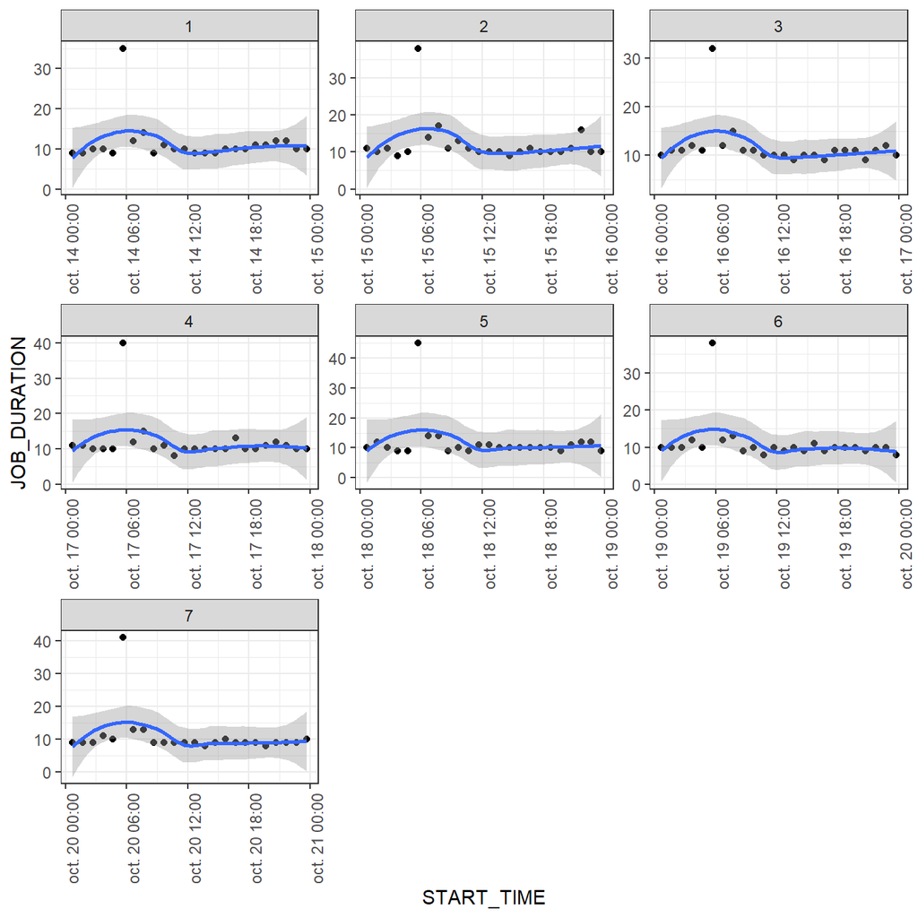

```r
# On plot la durée des jobs pour une semaine prise au hasard parmi les obs de la chronique 1
obs <- df_ID1[60:227,]

ggplot(obs,aes(x = START_TIME, y=JOB_DURATION)) +
  geom_point() +
  geom_smooth() +
  facet_wrap(~Day, scales='free') +
  theme_bw() +
  theme(axis.text.x = element_text(angle=90))
```

Avec une semaine prise au hasard parmi les observations de la chronique 1, par défaut avec la fonction *ggplot()* on voit que l’ajustement est mauvais, d’où l’intérêt de réaliser des modèles GAM où l’on pourra spécifier chaque paramètre de la régression.

## 2-Modélisations des durées des jobs

Nous allons dans cette partie commencer les modélisations des durées des jobs, en construisant par un modèle simple GAM par chronique puis en essayant d’optimiser les paramètres et ainsi améliorer les prévisions. Pour évaluer la performance des modèles nous regarderons différentes choses :

- **R2** : qui représente le pourcentage de la variance expliquée par le modèle (sa qualité d’ajustement)
- **Significativité des variables** : on ne conserve que les modèles où toutes les variables sont significatives en respectant le critère de parcimonie
- **Visualisation graphique** : sur un même graphique nous confronterons les valeurs prédites par le modèle aux données observées pour une semaine tirée au hasard et non toute la période pour une meilleure lisibilité

Aussi, pour comparer les modèles entre eux nous regarderons les critères suivants :

- **GCV** : qui donne la moyenne des erreurs des estimations par validation croisée
- **AIC** = 2 log(L) − 2p avec L le Log de Vraisemblance du modèle et p le nombre de paramètres
- **MAPE** : qui donne la moyenne des erreurs absolues des prévisions en pourcentage

Toutes ces informations auront pour but de constater la qualité de nos prévisions et ainsi sélectionner le meilleur modèle, c’est à dire celui qui maximise le $R^2$ et minimise l’AIC, le GCV et le MAPE.

### 2.1 Fonctionnement d’un modèle GAM

Introduit dès les années 80, le modèle additif généralisé (GAM) permet de traiter des relations non linéaires que peuvent prendre les variables explicatives, en s’affranchissant de la linéarité pour mieux prendre en compte les seuils et les valeurs extrêmes. Le principe d’un GAM est ainsi d’expliquer une phénomène non par des variables explicatives mais par des fonctions de ces dernières : appelées fonctions de lissage non paramétriques ou non spécifiques. Effectivement, aucun paramètre n’est nécessaire à la construction de GAM ; la distribution de la variable à expliquer peut alors prendre la forme d’une loi binomiale, d’une loi de Poisson, de Gamma etc. Le modèle linéaire général est ainsi un cas particulier du modèle linéaire généralisé, où Y suit une loi normale et où les fonctions de liaisons avec les variables explicatives sont de simples fonctions identité telles que f(x)=x.

Pour étudier le comportement des fonctions sur Y, il convient de définir et estimer les fonctions non linéaires $f_{j}$ qui remplacent les coefficients $\beta_{j}$. Valables pour les variables quantitatives, ces fonctions permettent de maximiser la qualité de la prévision de Y et ainsi augmenter les performances des modèles construits. Dans le cadre de ce travail nous cherchons à obtenir les meilleures prévisions des durées de différents “jobs” en secondes, c’est pourquoi nous aurons recours aux modèles additifs généralisés.

Plusieurs paramètres entrent en compte lors de l’estimation de GAM et leur ajustement peut permettre une meilleure qualité prévisionnelle, nous jouerons donc sur les paramètres suivants :

- **k** : le nombre de fonctions de base, plus il augmente plus le nombre d’observations dans la base doit être grand du fait des nombreux paramètres à estimer, autremit dit k découpe l’espace et définit la précision de la régression
- **sp** : le nombre de splines, une spline représente un polynome de degré $k$ qui a un instant t vaut 1 et à tous les autres vaut 0 ; on peut alors fixer $sp$ le nombre maximum de splines sur un espace k. Attention, $sp=\frac{1}{nb de splines}$ donc plus $s$ est petit plus le nombre de splines est élevé. Il existe 2 types de splines ; les paramétriques (splines de régression/pénalisés) et les non-paramétriques (splines de lissage)
- **method** : la méthode d’estimation des paramètres de lissage, lorsque l’on fixe *method=“REML”* alors le modèle cherche lui-même les meilleurs paramètres de régression. La méthode “GCV” prédit Y par cross-validation et peut aussi être intéressante
- **bs** : le type de spline de régression parmi “thin plate” (par défaut), “cubic regression”, “cyclic”, “duchon”, “on the sphere” splines etc.
- **knots** : les nœuds représentent les intervalles auxquels doivent être construites les fonctions de base, on peut donc définir ces intervalles

Par la combinaison de tous ces paramètres on cherche la fonction la plus lisse mais qui soit la plus précise possible pour modéliser Y, on cherche le compromis entre le log de vraisemblance du modèle et sa complexité - compromis définit par le paramètre de lissage $\lambda$. L’idée d’un GAM est d’utiliser une forme plus flexible de régression entre Y et X ; mais un $\lambda$ trop petit conduit à une régression trop précise et donc inefficace qu’on appelle *over-fiting* ou *sur-apprentissage* (le cas extrême correspondant à une fonction de base par observation). La complexité est aussi observable par l’edf (estimation du nombre de degrés de liberté) qui représente de combien la variable est lissée donc plus l’edf est grand et plus les splines ont une forme complexe.

### 2.2 Application de modèles GAM

#### ID 1

Pour les modélisations nous procéderons à la même approche pour les 3 ID ; nous modéliserons dans un premier temps un modèle additif généralisé le plus simple possible, en incluant les variables qui vont avec la chronique mais sans préciser de paramètres énumérés ci-dessus. Puis, petit à petit nous effectuerons une recherche du meilleur modèle en testant différents paramètres jusqu’à trouver les prévisions les plus justes.

##### Modélisations

###### 1er GAM

```r
# On estime un premier modèle gam le plus simple possible c-à-d. sans rien définir
gam1_ID1 <- gam(formula=JOB_DURATION ~ TAP_VERSION + s(Week) + s(Day,k=1) + s(Hour), data = df_ID1, method="REML")
summary(gam1_ID1) #R2=0.348
##
## Family: gaussian
## Link function: identity
##
## Formula:
## JOB_DURATION ~ TAP_VERSION + s(Week) + s(Day, k = 1) + s(Hour)
##
## Parametric coefficients:
##                   Estimate Std. Error t value Pr(>|t|)
## (Intercept)       12.46087    0.15400  80.915   <2e-16 ***
## TAP_VERSION1.16.0 -0.23851    0.46818  -0.509   0.6105
## TAP_VERSION1.17.0  0.07533    1.34894   0.056   0.9555
## TAP_VERSION1.17.1  0.15173    1.07576   0.141   0.8878
## TAP_VERSION1.17.2 -0.17043    0.56229  -0.303   0.7618
## TAP_VERSION1.17.3 -1.64044    0.50608  -3.241   0.0012 **
## ---
## Signif. codes:  0 '***' 0.001 '**' 0.01 '*' 0.05 '.' 0.1 ' ' 1
##
## Approximate significance of smooth terms:
##           edf Ref.df       F  p-value
## s(Week) 3.350  4.064   6.596 2.24e-05 ***
## s(Day)  1.868  1.982   3.506   0.0249 *
## s(Hour) 8.975  9.000 290.297  < 2e-16 ***
## ---
## Signif. codes:  0 '***' 0.001 '**' 0.01 '*' 0.05 '.' 0.1 ' ' 1
##
## R-sq.(adj) =  0.348   Deviance explained = 35.1%
## -REML =  15794  Scale est. = 32.355    n = 4992
```

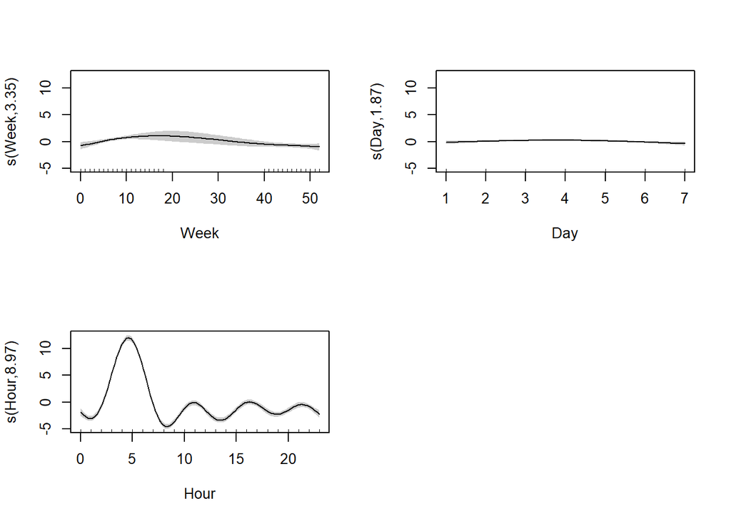

```r
plot(gam1_ID1,residuals=FALSE, shade=TRUE, pages=1)
```

L’utilité de considérer des fonctions des variables explicatives peut se confirmer par les plots des résidus où nous observons clairement des seuils et des variations pour la variable ‘Hour’, une relation légèrement incurvée pour les numéros des semaines, et une quasiment linéaire pour le jour de la semaine sur les temps d’exécution des jobs.

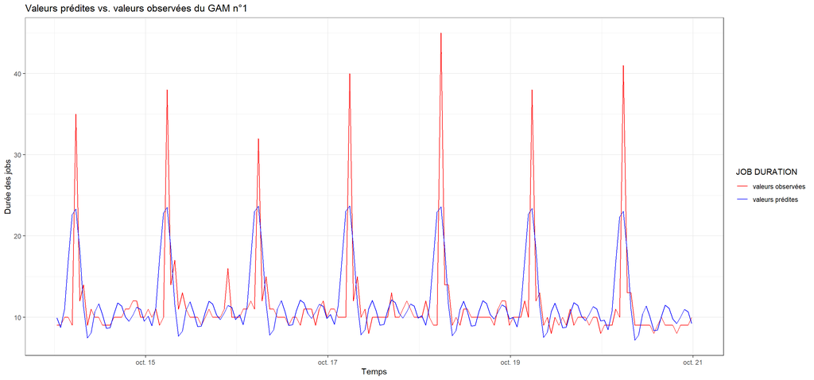

```r
# On plote les valeurs prédites et les valeurs observées pour voir la qualité du modèle simple
fitted <- gam1_ID1$fitted.values
real_ID1 <- df_ID1$JOB_DURATION
date_ID1 <- df_ID1[,2]

prev <- cbind(date_ID1, real_ID1, fitted)
prev <- data.frame(prev)

ggplot(data=prev[60:227,])+
  geom_line(mapping=aes(y=real_ID1,x= START_TIME,color="valeurs observées")) +
  geom_line(mapping=aes(y=fitted,x= START_TIME,color="valeurs prédites")) +
  theme_bw() +
  scale_color_manual(values = c(
    'valeurs prédites' = 'blue',
    'valeurs observées' = 'red')) +
  labs(color = 'JOB DURATION', x = "Temps", y = "Durée des jobs",
       title = "Valeurs prédites vs. valeurs observées du GAM n°1")
```

Sur le graphique ci-dessus nous pouvons constater les valeurs prédites par le modèle (en bleu) et les valeurs observées de Y (en rouge) ; nous voyons que ce premier GAM a du mal à modéliser une si grande volatilité et capte mal les valeurs importantes que nous voyons tous les jours à 5h41 pour la chronique 1. On cherche donc a améliorer ce modèle en prenant en compte les constats faits lors de son analyse.